# Tutorial for bioregion

Maxime Lenormand, Boris Leroy and Pierre Denelle

2026-03-29

## 0. Brief introduction

This tutorial aims at describing the different features of the R package `bioregion`. The main purpose of the `bioregion`‘s package is to propose a transparent methodological framework to compare bioregionalization methods. Below is the typical flow chart of bioregions’ identification based on a site-species bipartite network or co-occurrence matrix with `bioregion` (Figure 1). This workflow can be divided into four main steps:

1. Preprocess the data (matrix or network formats)
2. Compute similarity/dissimilarity metrics between sites based on species composition
3. Run the different algorithms to identify different set of bioregions
4. Evaluate and visualize the results

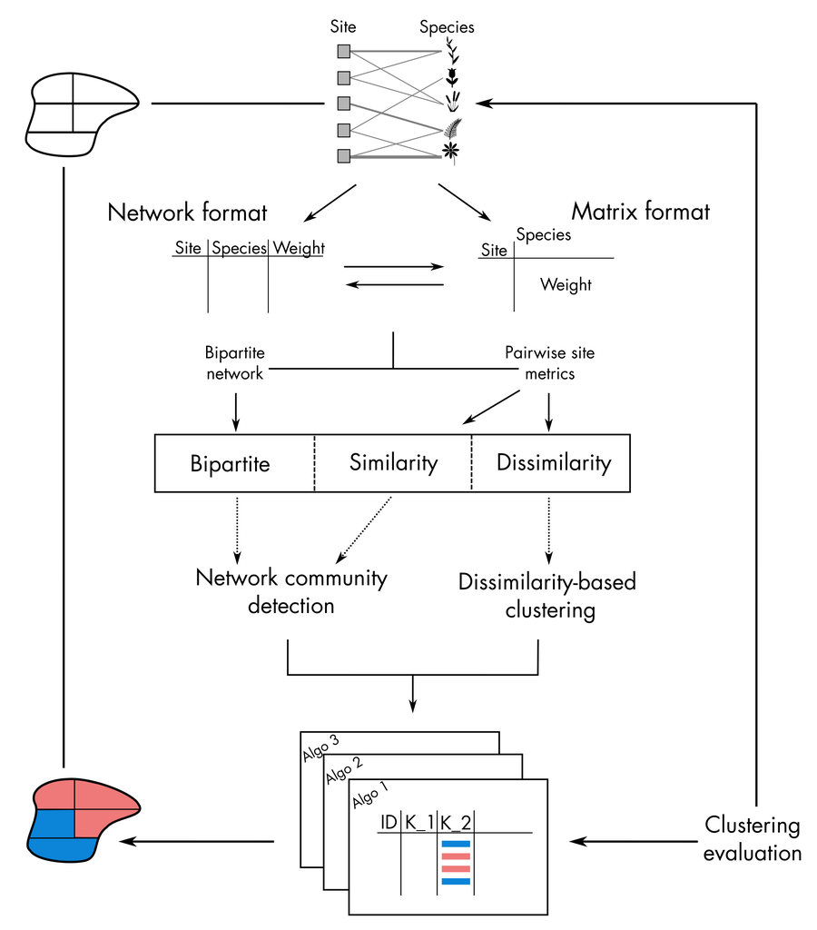

**Figure 1: Workflow of the bioregion’s package.**

Please see this [tutorial page](https://bioRgeo.github.io/bioregion/articles/a0_terminology.html) for notes on the terminology used in the package.

## 1. Install binary files

Some functions or at least part of them (listed below) require binary files to run.

- [netclu_infomap](https://bioRgeo.github.io/bioregion/reference/netclu_infomap.html)
- [netclu_louvain](https://bioRgeo.github.io/bioregion/reference/netclu_louvain.html) (Cpp version)
- [netclu_oslom](https://bioRgeo.github.io/bioregion/reference/netclu_oslom.html)

Please see this [tutorial page](https://bioRgeo.github.io/bioregion/articles/a1_install_binary_files.html) to get instructions regarding the installation of the binary files.

## 2. Matrix or network formats

The `bioregion`’s package takes as input site-species information stored in a bipartite network or a co-occurrence matrix. Relying on the function [mat_to_net](https://bioRgeo.github.io/bioregion/reference/mat_to_net.html) and [net_to_mat](https://bioRgeo.github.io/bioregion/reference/net_to_mat.html) , it handles both the matrix and network formats throughout the workflow.

Please see this [tutorial page](https://bioRgeo.github.io/bioregion/articles/a2_matrix_and_network_formats.html) to better understand how these two functions work.

## 3. Pairwise similarity/dissimilarity metrics

The functions [similarity](https://bioRgeo.github.io/bioregion/reference/similarity.html) and [dissimilarity](https://bioRgeo.github.io/bioregion/reference/dissimilarity.html) compute respectively pairwise similarity and dissimilarity metrics based on a (site-species) co-occurrence matrix. The resulting `data.frame` is stored in a `bioregion.pairwise` object containing all requested metrics between each pair of sites.

The functions [dissimilarity_to_similarity](https://bioRgeo.github.io/bioregion/reference/dissimilarity_to_similarity.html) and [similarity_to_dissimilarity](https://bioRgeo.github.io/bioregion/reference/dissimilarity_to_similarity.html) can be used to transform a similarity object into a dissimilarity object and vice versa.

The function [as_bioregion_pairwise](https://bioRgeo.github.io/bioregion/reference/as_bioregion_pairwise.html) allows to convert a (dis)similarity `matrix` or a `list` of such matrices into a `bioregion.pairwise` object compatible with the `bioregion` package. The input can come from base R, `dist` objects, or outputs from other packages.

Please see this [tutorial page](https://bioRgeo.github.io/bioregion/articles/a3_pairwise_metrics.html) to better understand how these functions work.

## 4. Bioregionalization algorithms

The `bioregion` R package gathers several methods allowing to group sites and species into similar entities called bioregions. All these methods can lead to several partitions of sites and species, i.e. to different bioregionalizations.  
Bioregionalization methods can be based on hierarchical clustering algorithms, non-hierarchical clustering algorithms or network algorithms.  
The functions in the package are related to each of these three families and produce output that have a specific class, namely the `bioregion.clusters` class.

### 4.1 Hierarchical clustering

The functions relying on hierarchical clustering start with the prefix `hclu_`. With these algorithms, the bioregions are placed into a dendrogram that ranges from two extremes: all sites belong to the same bioregion (top of the tree) or all sites belong to a different bioregion (bottom of the tree).

Please see this [tutorial page](https://biorgeo.github.io/bioregion/articles/a4_1_hierarchical_clustering.html) for more details.

### 4.2 Non-hierarchical clustering

The functions relying on hierarchical clustering start with the prefix `nhclu_`. For most of these algorithms, the user needs to predefine the number of clusters, although this number can be determined by estimating the optimal bioregionalization.

Please see this [tutorial page](https://biorgeo.github.io/bioregion/articles/a4_2_non_hierarchical_clustering.html) for more details.

### 4.3 Network clustering

The functions relying on network clustering start with the prefix `netclu_`. Site-species matrices can be seen as (bipartite) networks where the nodes are either the sites or the species and the links between them are the occurrences of species within sites.  
With networks, modularity algorithms can be applied, leading to bioregionalization.

The following [tutorial page](https://bioRgeo.github.io/bioregion/articles/a4_3_network_clustering.html) details more each clustering functions relying on a network algorithm.

### 4.4 Microbenchmark

The different bioregionalization methods listed in the package rely on more or less computationally intensive algorithms.

The following [page](https://biorgeo.github.io/bioregion/articles/a4_4_microbenchmark.html) estimates the time required to run each method on data sets of different sizes.

## 5. Visualization and evaluation of the results

## 5.1 Visualization

If sites have geographic coordinates, then each bioregionalization can be visualized with the function `map_bioregions()`.

This [tutorial page](https://biorgeo.github.io/bioregion/articles/a5_1_visualization.html) details different ways to plot your bioregionalization.

## 5.2 Summary metrics

In this section, we compute summary statistics at different scales, either at the bioregion or at the site or species level. Related functions are detailed in this [page](https://biorgeo.github.io/bioregion/articles/a5_2_summary_metrics.html).

## 5.3 Compare bioregionalizations

In this section, we look at how sites are assigned to bioregions within a single bioregionalization and also compare this assignment across different bioregionalizations. The following [page](https://biorgeo.github.io/bioregion/articles/a5_3_compare_bioregionalizations.html) illustrates this.